# STATS 101A Final Project

ISAAC YU - GROUP 12

03/09/25

```r
library(car)
library(leaps)
```

## Dataset Import & Data Cleaning

Observing the data before implementing any models, we saw that we needed to either remove entries and/or interpolate observations due to NULL values. At a glance, we wanted to engineer a model to predict the gross revenue of a movie based on the following numerical variables: Budget, Run time, Rating, and Rating Count. This would mean we do not need to implement a logistic regression model nor create any dummy variables for categorical variables. The reason why we chose not to utilize any categorical variables in our model was because 1. it would be difficult and tedious to force variables, such as Genre and MPAA Rating, into binary categorical variables. Below shows how we imported the dataset, removed unnecessary observations, altered data types, and checked for NULL values and interpolated them.

```r
# Import data & store
movies <- read.csv("movies.csv")
head(movies)
```

```
##   index MovieID                      Title MPAA.Rating   Budget     Gross
## 1     0       1         Look Who's Talking       PG-13  7500000 296000000
## 2     1       2         Driving Miss Daisy          PG  7500000 145793296
## 3     2       3             Turner & Hooch          PG 13000000  71079915
## 4     3       4 Born on the Fourth of July           R 14000000 161001698
## 5     4       5            Field of Dreams          PG 15000000  84431625
## 6     5       6                 Uncle Buck          PG 15000000  79258538
##   Release.Date   Genre Runtime Rating Rating.Count
## 1   1989-10-12 Romance      93    5.9        73638
## 2   1989-12-13  Comedy      99    7.4        91075
## 3   1989-07-28   Crime     100    7.2        91415
## 4   1989-12-20     War     145    7.2        91415
## 5   1989-04-21   Drama     107    7.5       101702
## 6   1989-08-16  Family     100      7        77659
##                                                                                                                                                                                                                                                                     Summary
## 1                                      After a single, career-minded woman is left on her own to give birth to the child of a married man, she finds a new romantic chance in a cab driver. Meanwhile, the point-of-view of the newborn boy is narrated through voice-over.
## 2                                                                                                                                  An old Jewish woman and her African-American chauffeur in the American South have a relationship that grows and improves over the years.
## 3 Det. Scott Turner (Tom Hanks) is an uptight, by-the-book police officer. When his friend Amos Reed (John McIntire), the proprietor of a junkyard, is killed, Turner reluctantly inherits the man's dog. Turner adjusts to life with the dog to help solve a murder case.
## 4                                                                                             The biography of Ron Kovic. Paralyzed in the Vietnam war, he becomes an anti-war and pro-human rights political activist after feeling betrayed by the country he fought for.
## 5                                                                                                                An Iowa corn farmer, hearing voices, interprets them as a command to build a baseball diamond in his fields; he does, and the 1919 Chicago White Sox come.
## 6                                                                                                                                               Bachelor and all-round slob Buck babysits his brothers rebellious teenage daughter and her cute younger brother and sister.
```

```r
# Need to remove observations 511 - nrow(movies)
movies[510:519, ]
```

```
##     index MovieID                   Title    MPAA.Rating      Budget     Gross
## 510   509     510 Guardians of the Galaxy          PG-13   170000000 773328629
## 511   510 MovieID                 ActorID Character Name creditOrder       pay
## 512   511       1                       1          James           1
## 513   512       1                       2         Mollie           2
## 514   513       1                       3          Rosie           3
## 515   514       1                       4         Albert           4
## 516   515       1                       5        Grandpa           5
## 517   516       1                       6          Mikey           6
## 518   517       1                       7           Rona           7
## 519   518       1                       8          Mikey           8
##     Release.Date  Genre Runtime Rating Rating.Count
## 510   2014-07-30 Action     121      8       978222
## 511   screentime
## 512
## 513
## 514
## 515
## 516
## 517
## 518
## 519
##                                                                                                                 Summary
## 510 A group of intergalactic criminals must pull together to stop a fanatical warrior with plans to purge the universe.
## 511
## 512
## 513
## 514
## 515
## 516
## 517
## 518
## 519
```

```r
# Removes unnecessary observations
movies <- movies[1:510, ]
nrow(movies)
```

```
## [1] 510
```

From observations 511 onward, the data does not make any sense, so they would not be sufficient in the model. As a result, they must be removed and we only utilized 510 observations in the dataset.

```r
# Remove the Summary variable to make our dataset more clear and clean
movies$Summary <- NULL

# All columns of the dataset are of the character data type, so need to manipulate them into numeric to use in a Linear Regression model
str(movies)
```

```
## 'data.frame':    510 obs. of  11 variables:
##  $ index       : int  0 1 2 3 4 5 6 7 8 9 ...
##  $ MovieID     : chr  "1" "2" "3" "4" ...
##  $ Title       : chr  "Look Who's Talking" "Driving Miss Daisy" "Turner & Hooch" "Born on the Fourth of July" ...
##  $ MPAA.Rating : chr  "PG-13" "PG" "PG" "R" ...
##  $ Budget      : chr  "7500000" "7500000" "13000000" "14000000" ...
##  $ Gross       : chr  "296000000" "145793296" "71079915" "161001698" ...
##  $ Release.Date: chr  "1989-10-12" "1989-12-13" "1989-07-28" "1989-12-20" ...
##  $ Genre       : chr  "Romance" "Comedy" "Crime" "War" ...
##  $ Runtime     : chr  "93" "99" "100" "145" ...
##  $ Rating      : chr  "5.9" "7.4" "7.2" "7.2" ...
##  $ Rating.Count: chr  "73638" "91075" "91415" "91415" ...
```

```r
# Manipulating columns into numeric
movies$Budget <- as.numeric(movies$Budget)
movies$Gross <- as.numeric(movies$Gross)
movies$Runtime <- as.numeric(movies$Runtime)
movies$Rating <- as.numeric(movies$Rating)
movies$Rating.Count <- as.numeric(movies$Rating.Count)
str(movies)
```

```
## 'data.frame':    510 obs. of  11 variables:
##  $ index       : int  0 1 2 3 4 5 6 7 8 9 ...
##  $ MovieID     : chr  "1" "2" "3" "4" ...
##  $ Title       : chr  "Look Who's Talking" "Driving Miss Daisy" "Turner & Hooch" "Born on the Fourth of July" ...
##  $ MPAA.Rating : chr  "PG-13" "PG" "PG" "R" ...
##  $ Budget      : num  7500000 7500000 13000000 14000000 15000000 15000000 16000000 16400000 20000000 25000000 ...
##  $ Gross       : num  2.96e+08 1.46e+08 7.11e+07 1.61e+08 8.44e+07 ...
##  $ Release.Date: chr  "1989-10-12" "1989-12-13" "1989-07-28" "1989-12-20" ...
##  $ Genre       : chr  "Romance" "Comedy" "Crime" "War" ...
##  $ Runtime     : num  93 99 100 145 107 100 96 129 124 114 ...
##  $ Rating      : num  5.9 7.4 7.2 7.2 7.5 7 7.6 8.1 7 7.2 ...
##  $ Rating.Count: num  73638 91075 91415 91415 101702 ...
```

```r
# Tests if there are any NA values in the Dataset
movies[is.na(movies[, c("Budget", "Gross", "Runtime", "Rating", "Rating.Count")])]
```

```
## [1] "PG-13"     "PG"        "160000000" "200000000" "130"       "130"
## [7] NA          NA
```

We have at least one NULL values for Rating and Rating Count. Must check histogram to see what to interpolate the values with.

```r
# There are two entries where there are NULL values for Rating or Rating Count
sum(is.na(movies$Rating))
```

```
## [1] 2
```

```r
movies <- subset(movies, !is.na(movies$Rating))
sum(is.na(movies$Rating.Count))
```

```
## [1] 0
```

```r
movies <- subset(movies, !is.na(movies$Rating.Count))

# No more NULL values
sum(is.na(movies$Rating))
```

```
## [1] 0
```

```r
sum(is.na(movies$Rating.Count))
```

```
## [1] 0
```

There are now no NULL values within in the dataset and the data is now prepared to be fit onto the regression model.

## Developing the Intial Model

For our initial model, we wanted to predict Gross Revenue based on the following predictor variables: Budget, Run time, Rating, and Rating Count. Since they are all numerical variables, implementing a linear regression model is appropriate.

```r
attach(movies)
```

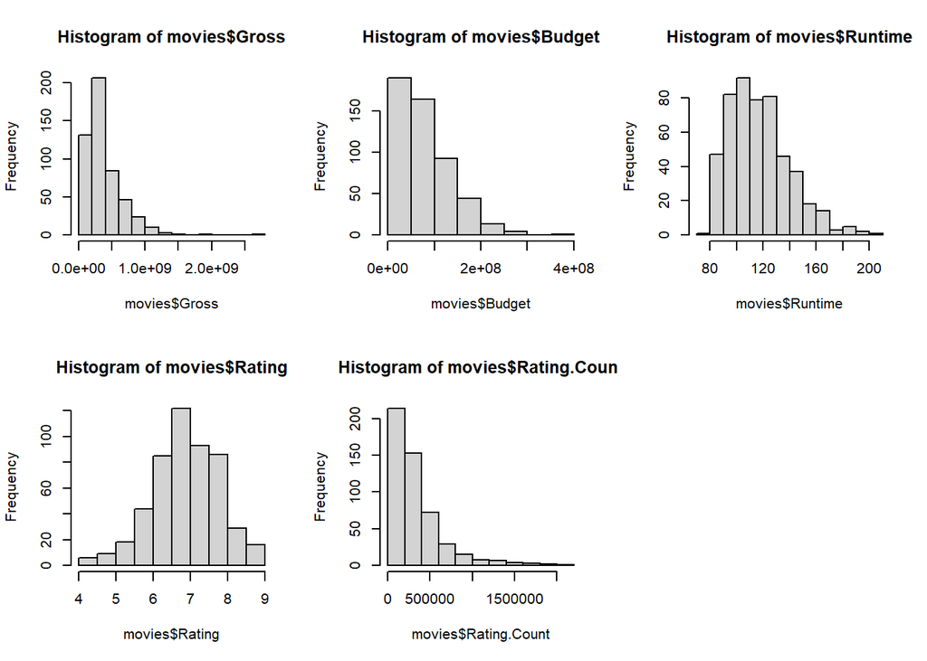

```r
# Create histogram matrix
par(mfrow = c(2,3))
hist(movies$Gross)
hist(movies$Budget)
hist(movies$Runtime)
hist(movies$Rating)
hist(movies$Rating.Count)
```

All variables seem to be right skewed except for Rating. This would hint that we would need to manipulate the response and predictor variables in order to make them jointly normal for the model.

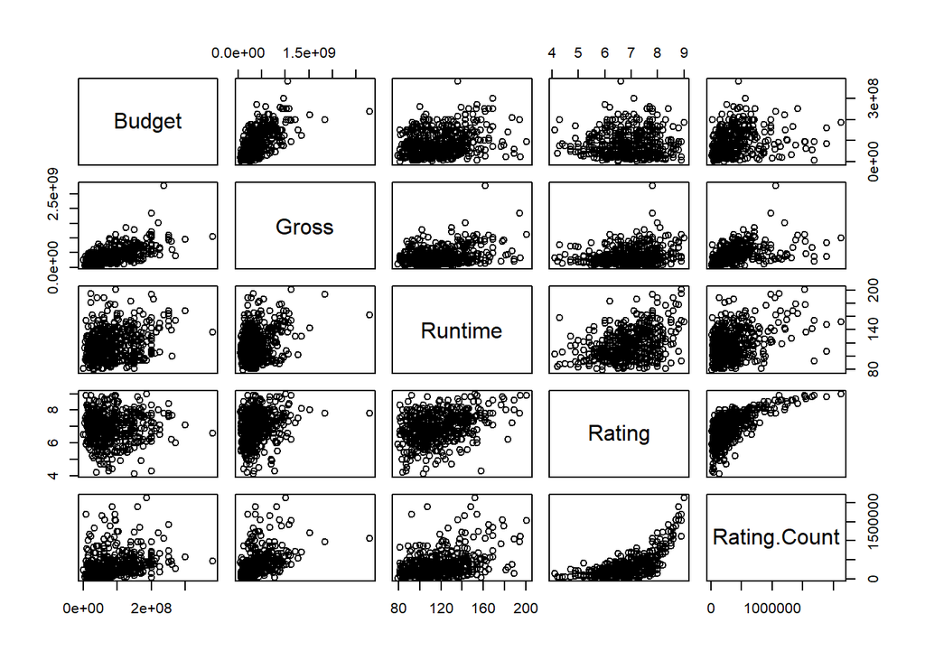

```r
# Create a correlation matrix of all variables
pairs(movies[, c("Budget", "Gross", "Runtime", "Rating", "Rating.Count")])
```

Many nonlinear relationships in the data, as shown by the correlation matrix. A non-linear relationship between Rating and Rating count is observed so it might hint towards multicollinearity in our model. However, other variables do not seem that highly correlated with one another, therefore we will still check to see if Rating and Rating Count contribute towards multicollinearity in our model using VIF.

```r
# Developing the intial model
m1 <- lm(Gross~Budget+Runtime+Rating+Rating.Count, data = movies)
summary(m1)
```

```
##
## Call:
## lm(formula = Gross ~ Budget + Runtime + Rating + Rating.Count,
##     data = movies)
##
## Residuals:
##        Min         1Q     Median         3Q        Max
## -519221703 -100018050  -24676679   72329617 1792675223
##
## Coefficients:
##                Estimate Std. Error t value Pr(>|t|)
## (Intercept)   5.487e+07  9.080e+07   0.604    0.546
## Budget        2.531e+00  1.568e-01  16.142  < 2e-16 ***
## Runtime       4.913e+05  4.204e+05   1.169    0.243
## Rating       -5.891e+06  1.349e+07  -0.437    0.663
## Rating.Count  2.883e+02  3.858e+01   7.474 3.48e-13 ***
## ---
## Signif. codes:  0 '***' 0.001 '**' 0.01 '*' 0.05 '.' 0.1 ' ' 1
##
## Residual standard error: 190600000 on 503 degrees of freedom
## Multiple R-squared:  0.5319, Adjusted R-squared:  0.5282
## F-statistic: 142.9 on 4 and 503 DF,  p-value: < 2.2e-16
```

Only 2 significant predictor variables, very large RSE (s^2). Budget and Rating Count seem to be the only predictor variables that are significant in our initial model. The F-value is high and the p-value is significant, therefore we can conclude that one or more of the predictor variables are significant. Our R-squared value of 53.19% hint that 53.19% of the variance in Gross revenue is explained by the predictor variables. Definitely some room for improvement.

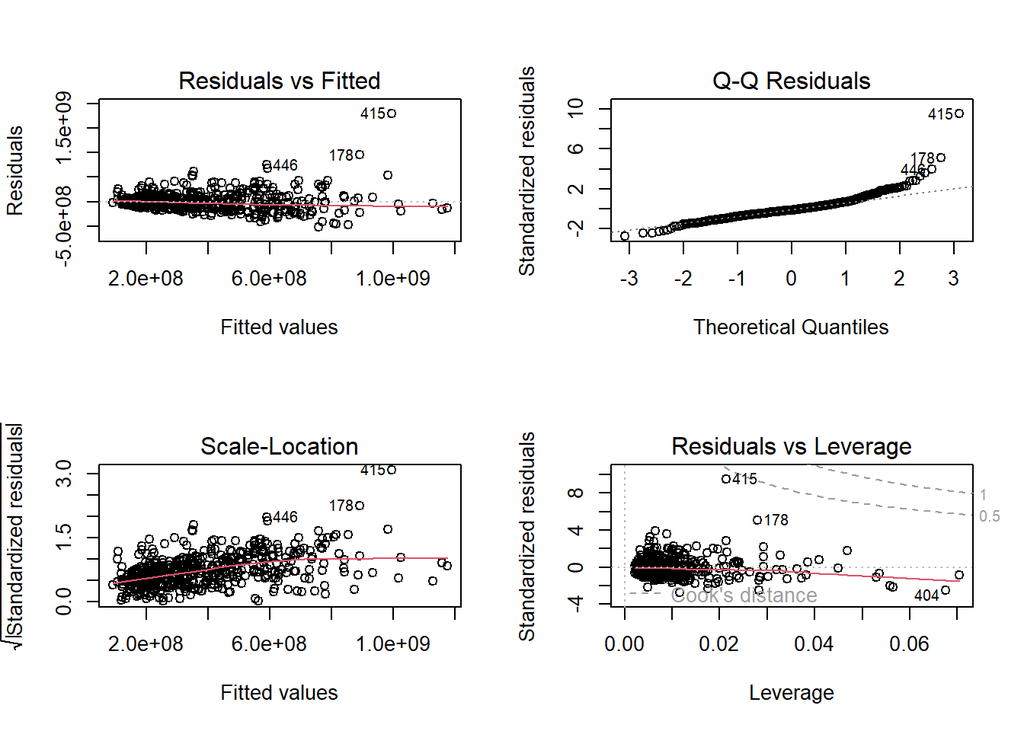

```r
#Diagnostic plots
par(mfrow = c(2, 2))
plot(m1)
```

Residual vs. Fitted: Seem to be centered around 0 and relatively straight. The assumption of linearity is withheld in our intial model. Does hint at some outliers, leverage points, and/or influential points. Normal Q-Q Plot: The points have heavy tails and deviate heavily from the reference line on the tails. Therefore the normality of the error terms assumption is violated. Scale-Location Plot: Some heavy grouping around lesser values of Y hat and points open up in a funnel shape around higher values of Y hat. Therefore, the assumption of constant variance is broken. Residuals vs. Leverage: Seem to be a moderate amount of outliers, leverage points, and influential points.

## Developing the Transformed Model

Since the initial model violates the regression assumptions, we must include transformations and manipulate the data in order to withhold the assumptions and uphold the predicting power of our model. As hinted earlier, the skewedness of each variable indicated that we would need to transform both the response and predictor variables.

```r
# Do a box-cox transformation for only predictor (X) variables
summary(powerTransform(cbind(Budget, Runtime, Rating, Rating.Count)~1), data = movies)
```

```
## bcPower Transformations to Multinormality
##              Est Power Rounded Pwr Wald Lwr Bnd Wald Upr Bnd
## Budget          0.3422        0.33       0.2619       0.4225
## Runtime        -0.3538        0.00      -0.7716       0.0640
## Rating          2.8858        2.89       2.3729       3.3987
## Rating.Count    0.2384        0.24       0.1673       0.3096
##
## Likelihood ratio test that transformation parameters are equal to 0
##  (all log transformations)
##                                  LRT df       pval
## LR test, lambda = (0 0 0 0) 250.8251  4 < 2.22e-16
##
## Likelihood ratio test that no transformations are needed
##                                  LRT df       pval
## LR test, lambda = (1 1 1 1) 788.9865  4 < 2.22e-16
```

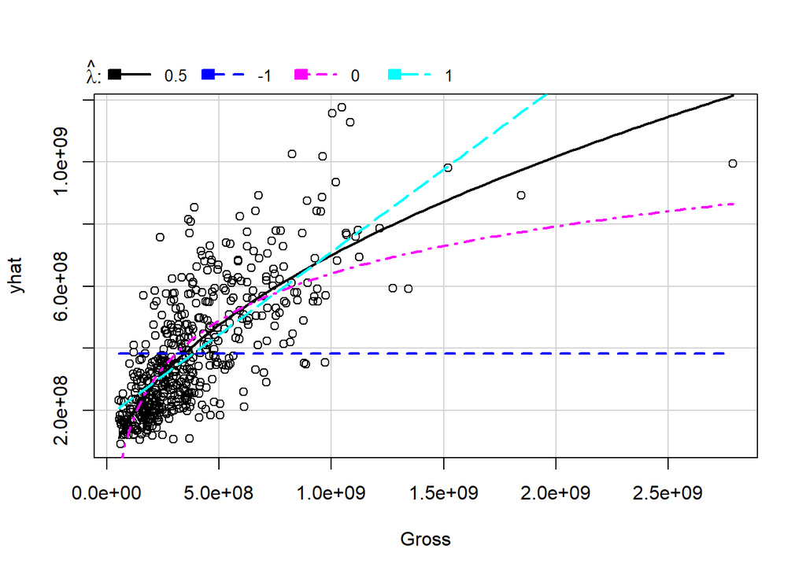

```
##       lambda          RSS
## 1  0.5013609 8.935574e+18
## 2 -1.0000000 2.076217e+19
## 3  0.0000000 9.662395e+18
## 4  1.0000000 9.718965e+18
```

```r
# Do an inverse-response plot for response (Y) variable
par(mfrow = c(1, 1))
inverseResponsePlot(m1, key = TRUE)
```

```r
# Do a box-cox transformation for BOTH response (Y) and predictor (X) variables
summary(powerTransform(cbind(Gross, Budget, Runtime, Rating, Rating.Count)~1), data = movies)
```

```
## bcPower Transformations to Multinormality
##              Est Power Rounded Pwr Wald Lwr Bnd Wald Upr Bnd
## Gross           0.0715        0.00      -0.0156       0.1586
## Budget          0.3783        0.33       0.3007       0.4559
## Runtime        -0.3510        0.00      -0.7704       0.0683
## Rating          2.8919        2.89       2.3799       3.4039
## Rating.Count    0.2149        0.21       0.1494       0.2804
##
## Likelihood ratio test that transformation parameters are equal to 0
##  (all log transformations)
##                                    LRT df       pval
## LR test, lambda = (0 0 0 0 0) 286.7333  5 < 2.22e-16
##
## Likelihood ratio test that no transformations are needed
##                                    LRT df       pval
## LR test, lambda = (1 1 1 1 1) 1192.728  5 < 2.22e-16
```

```r
# Transform data and put into a new dataset for clarity
transformed_movies <- data.frame(matrix(ncol = 5, nrow = nrow(movies)))
colnames(transformed_movies) <- c("Gross", "Budget", "Runtime", "Rating", "Rating.Count")
transformed_movies$Gross <- log(movies$Gross)
transformed_movies$Budget <- (movies$Budget)^0.33
transformed_movies$Runtime <- log(movies$Runtime)
transformed_movies$Rating <- (movies$Rating)^2.9
transformed_movies$Rating.Count <- (movies$Rating.Count)^0.21
head(transformed_movies)
```

```
##      Gross   Budget  Runtime   Rating Rating.Count
## 1 19.50587 185.6822 4.532599 171.9772     10.52183
## 2 18.79770 185.6822 4.595120 331.7203     11.00206
## 3 18.07932 222.6390 4.605170 306.3827     11.01067
## 4 18.89693 228.1509 4.976734 306.3827     11.01067
## 5 18.25145 233.4050 4.672829 344.8877     11.26002
## 6 18.18823 233.4050 4.605170 282.3477     10.63997
```

```r
# Plot transformed model
m2 <- lm(Gross~Budget+Runtime+Rating+Rating.Count, data = transformed_movies)
summary(m2)
```

```
##
## Call:
## lm(formula = Gross ~ Budget + Runtime + Rating + Rating.Count,
##     data = transformed_movies)
##
## Residuals:
##      Min       1Q   Median       3Q      Max
## -1.45198 -0.26548  0.01515  0.27180  1.09527
##
## Coefficients:
##                Estimate Std. Error t value Pr(>|t|)
## (Intercept)  16.5130007  0.4981454  33.149  < 2e-16 ***
## Budget        0.0028875  0.0002291  12.601  < 2e-16 ***
## Runtime       0.0201823  0.1113034   0.181    0.856
## Rating       -0.0015271  0.0002986  -5.114 4.49e-07 ***
## Rating.Count  0.1648336  0.0122725  13.431  < 2e-16 ***
## ---
## Signif. codes:  0 '***' 0.001 '**' 0.01 '*' 0.05 '.' 0.1 ' ' 1
##
## Residual standard error: 0.4198 on 503 degrees of freedom
## Multiple R-squared:  0.6178, Adjusted R-squared:  0.6147
## F-statistic: 203.3 on 4 and 503 DF,  p-value: < 2.2e-16
```

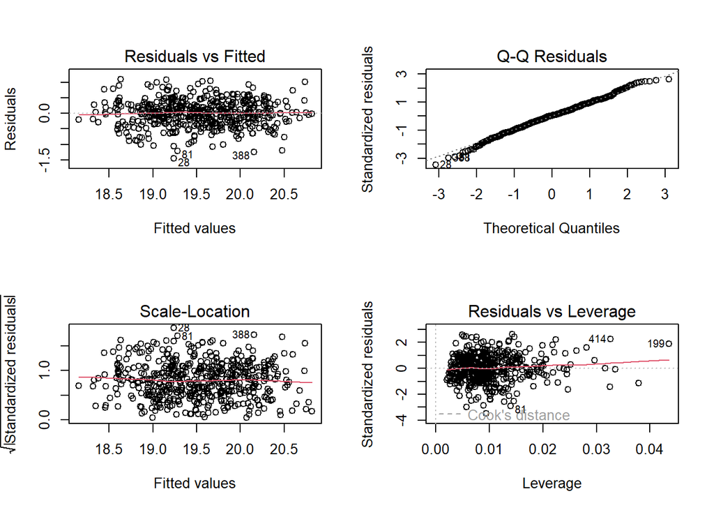

```r
par(mfrow = c(2, 2))
plot(m2)
```

Residuals vs. Fitted: Centered around 0, with random scattering of points. Red line is horizontal and straight, indicating linearity among variables. Linearity assumption holds. Normal Q-Q Plot: Points now follow along the reference line more closely. Upholds the normality assumption of error terms. Scale-Location Plot: Points seem more randomly scattered. Variance of the error term seems to be more or less constant. Residuals vs. Leverage Plot: Transformed model strongly reduced the number of outliers, leverage points, and influential points. However, we would still need to keep a look out for case 199 (more information on that later)

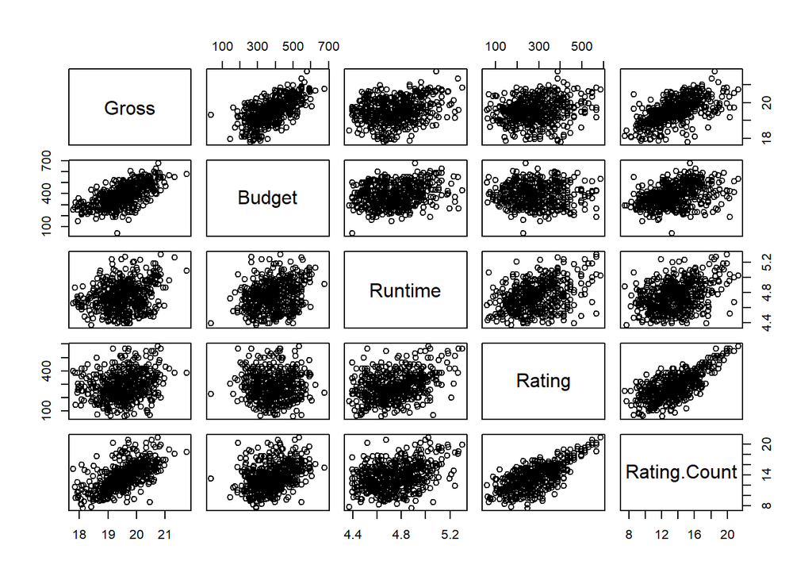

```r
pairs(Gross~Budget+Runtime+Rating+Rating.Count, data = transformed_movies)
```

Relationships among variables seem more linear, however Rating and Rating Count seem to be heavily correlated. Must check the VIF in order to check multicollinearity.

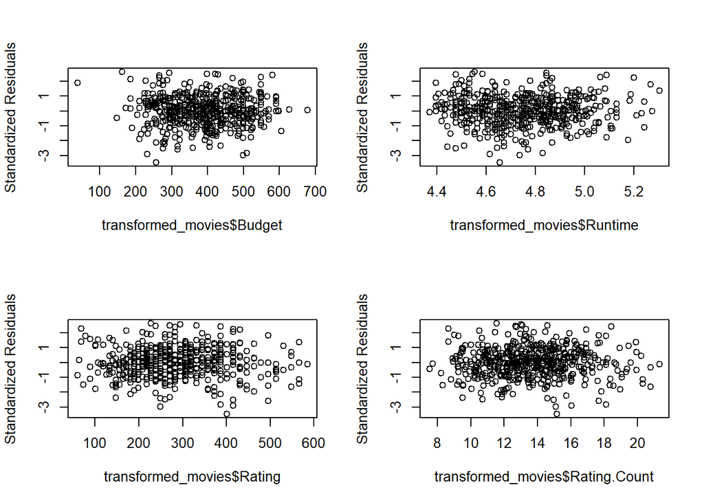

```r
par(mfrow = c(2, 2))
StandRes1 <- rstandard(m2)
plot(transformed_movies$Budget, StandRes1, ylab = "Standardized Residuals")
plot(transformed_movies$Runtime, StandRes1, ylab = "Standardized Residuals")
plot(transformed_movies$Rating, StandRes1, ylab = "Standardized Residuals")
plot(transformed_movies$Rating.Count, StandRes1, ylab = "Standardized Residuals")
```

Residuals seem randomly scattered. Model fits well with the data. However, there may be some slight heteroscedascity, but it is minimized by the transformations.

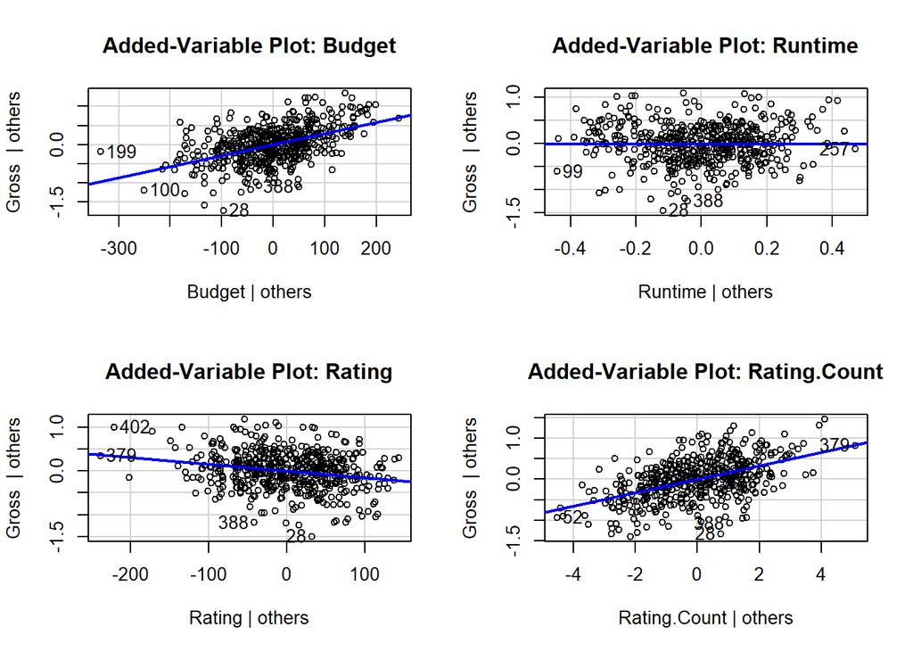

```r
par(mfrow = c(2,2))
avPlot(m2, variable = Budget, ask = FALSE)
avPlot(m2, variable = Runtime, ask = FALSE)
avPlot(m2, variable = Rating, ask = FALSE)
avPlot(m2, variable = Rating.Count, ask = FALSE)
```

As we could see from the significance level from the summary output, Run time has little effect on the response variable. AV plot supports the summary output gained from our transformed model.

```r
vif(m2)
```

```
##       Budget      Runtime       Rating Rating.Count
##     1.476086     1.244975     2.619602     2.851213
```

VIF shows that multicollinearity is not an issue (no values above 5). Therefore model/variable selection is not neccessary for our model.

## Making Model More Interpretable

However, with transformed data, it is difficult to interpret the outcome. For the sake of interpretability, we will consider log transformations paired alongside some power transformations in order to make our model more useful by others.

```r
# Box-cox transformation
summary(powerTransform(cbind(Gross, Budget, Rating, Rating.Count, Runtime)~1), data = movies)
```

```
## bcPower Transformations to Multinormality
##              Est Power Rounded Pwr Wald Lwr Bnd Wald Upr Bnd
## Gross           0.0715        0.00      -0.0156       0.1586
## Budget          0.3783        0.33       0.3007       0.4559
## Rating          2.8919        2.89       2.3799       3.4039
## Rating.Count    0.2149        0.21       0.1494       0.2804
## Runtime        -0.3510        0.00      -0.7704       0.0683
##
## Likelihood ratio test that transformation parameters are equal to 0
##  (all log transformations)
##                                    LRT df       pval
## LR test, lambda = (0 0 0 0 0) 286.7333  5 < 2.22e-16
##
## Likelihood ratio test that no transformations are needed
##                                    LRT df       pval
## LR test, lambda = (1 1 1 1 1) 1192.728  5 < 2.22e-16
```

We will conduct log transformations on Gross, Budget, Rating Count, and Run Time in order to see whether or not our model is valid.

```r
# Make a new dataset in order for clarity
log_movies <- data.frame(matrix(ncol = 5, nrow = nrow(movies)))
colnames(log_movies) <- c("Gross", "Budget", "Runtime", "Rating", "Rating.Count")
log_movies$Gross <- log(movies$Gross)
log_movies$Budget <- log(movies$Budget)
log_movies$Runtime <- log(movies$Runtime)
log_movies$Rating <- (movies$Rating)^2.89
log_movies$Rating.Count <- log(movies$Rating.Count)
```

```r
# Fit the data to the model to see the result
m3 <- lm(Gross~Budget+Runtime+Runtime+Rating+Rating.Count, data = log_movies)
summary(m3)
```

```
##
## Call:
## lm(formula = Gross ~ Budget + Runtime + Runtime + Rating + Rating.Count,
##     data = log_movies)
##
## Residuals:
##      Min       1Q   Median       3Q      Max
## -1.52896 -0.26449  0.01211  0.25951  1.76619
##
## Coefficients:
##                Estimate Std. Error t value Pr(>|t|)
## (Intercept)   8.3319033  0.5918376  14.078  < 2e-16 ***
## Budget        0.2895214  0.0261387  11.076  < 2e-16 ***
## Runtime       0.0825688  0.1145048   0.721    0.471
## Rating       -0.0015958  0.0002959  -5.393 1.07e-07 ***
## Rating.Count  0.4908938  0.0330039  14.874  < 2e-16 ***
## ---
## Signif. codes:  0 '***' 0.001 '**' 0.01 '*' 0.05 '.' 0.1 ' ' 1
##
## Residual standard error: 0.4323 on 503 degrees of freedom
## Multiple R-squared:  0.5946, Adjusted R-squared:  0.5913
## F-statistic: 184.4 on 4 and 503 DF,  p-value: < 2.2e-16
```

Again, our model sees that Budget, Rating, and Rating Count are significant predictors of Gross via the t-tests. The F-value is moderately high and our p-value is still significant meaning that one or more of the predictor variables are significant. Our R-squared is still more than our initial model, but slightly less than our first transformation.

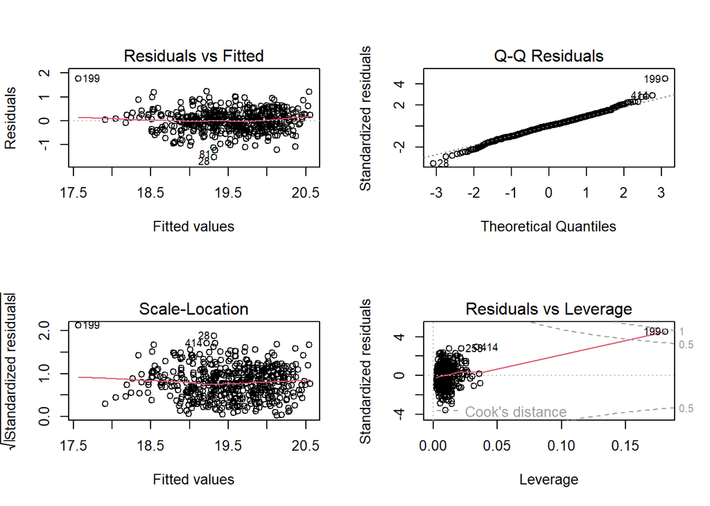

```r
# Examine whether or not the model is valid
par(mfrow = c(2,2))
plot(m3)
```

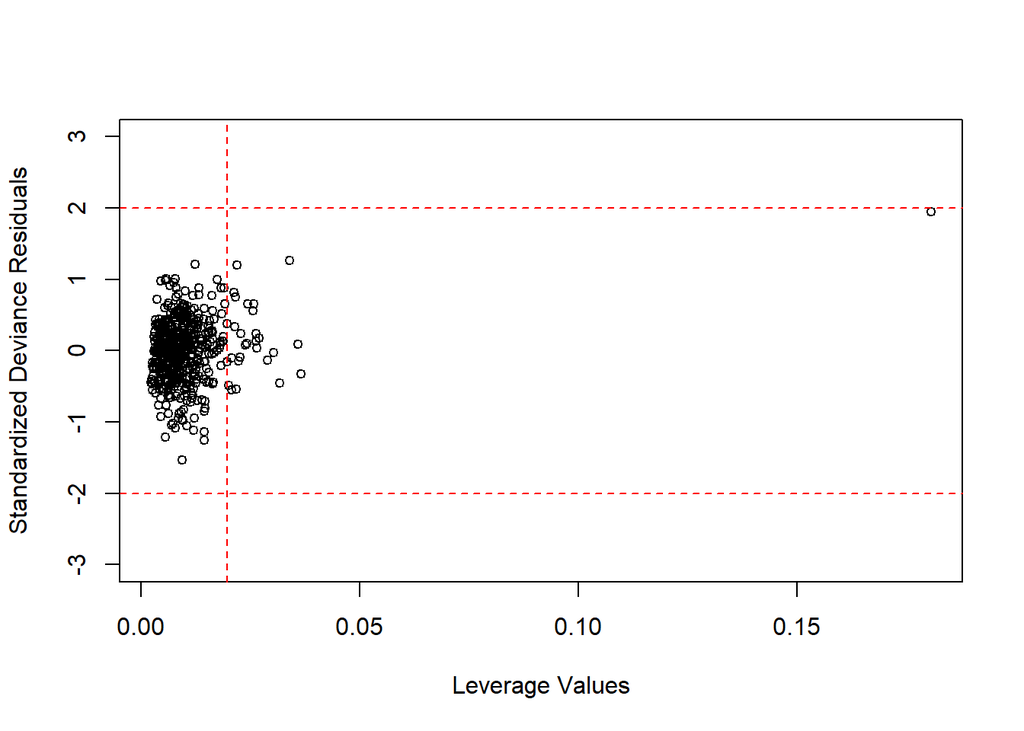

```r
p <- 4
n <- nrow(log_movies)
hvalues <- hatvalues(m3)
StandRes <- rstandard(m3)
standarddev <- residuals(m3) / sqrt(1 - hvalues)

plot(hvalues, standarddev, ylab = "Standardized Deviance Residuals", xlab = "Leverage Values", ylim = c(-3, 3), cex = 0.8)
abline(v = 2 * ((p + 1) / n), lty = 2, col = "red")
abline(h = 2, lty = 2, col = "red")
abline(h = -2, lty = 2, col = "red")
```

As you can see, case 199 is not a bad leverage point, just a leverage point. So we do not need to worry about case 19, instead just keep an eye on it.

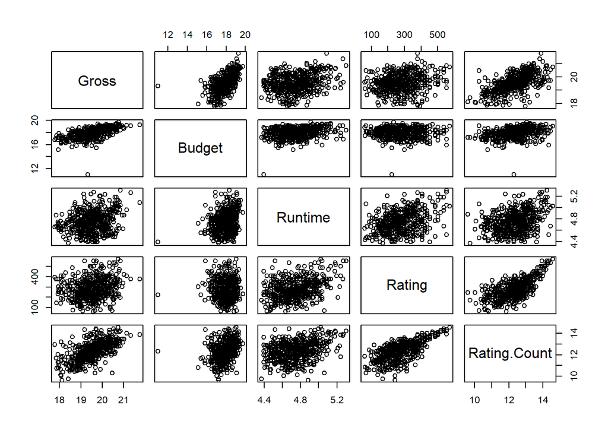

```r
pairs(Gross~Budget+Runtime+Rating+Rating.Count, data = log_movies)
```

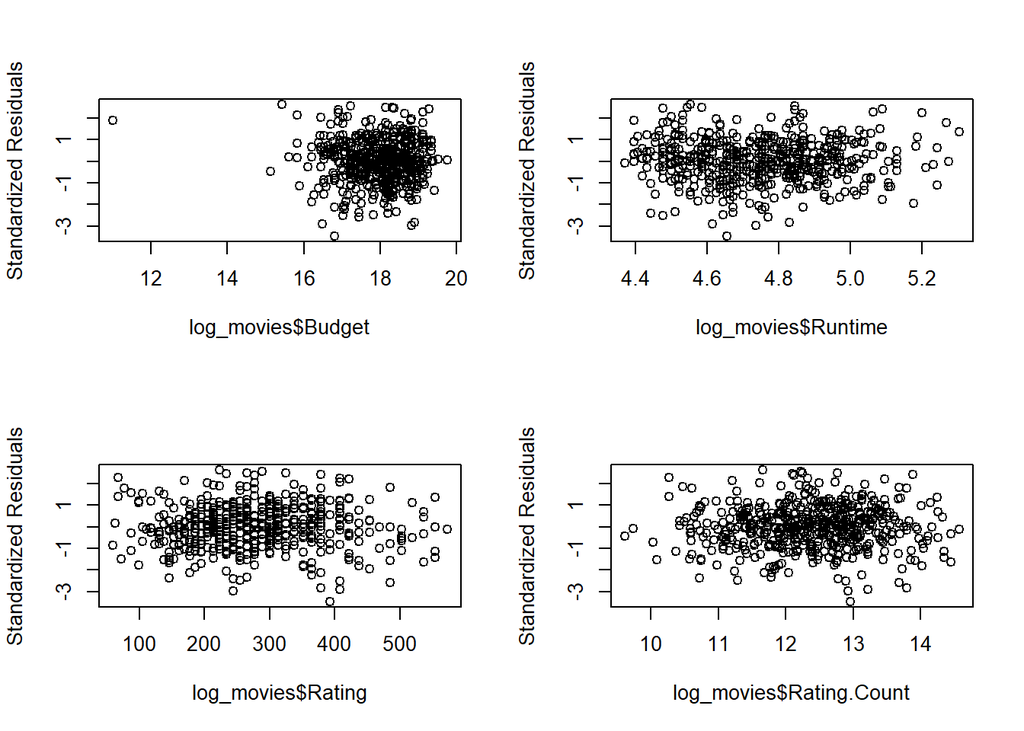

```r
par(mfrow = c(2, 2))
StandRes2 <- rstandard(m3)
plot(log_movies$Budget, StandRes1, ylab = "Standardized Residuals")
plot(log_movies$Runtime, StandRes1, ylab = "Standardized Residuals")
plot(log_movies$Rating, StandRes1, ylab = "Standardized Residuals")
plot(log_movies$Rating.Count, StandRes1, ylab = "Standardized Residuals")
```

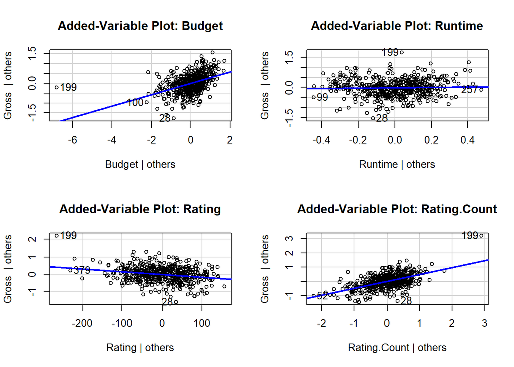

```r
par(mfrow = c(2,2))
avPlot(m3, variable = Budget, ask = FALSE)
avPlot(m3, variable = Runtime, ask = FALSE)
avPlot(m3, variable = Rating, ask = FALSE)
avPlot(m3, variable = Rating.Count, ask = FALSE)
```

```r
reduced_m3 <- lm(Gross~Budget+Rating+Rating.Count, data = log_movies)
anova(reduced_m3, m3)
```

```
## Analysis of Variance Table
##
## Model 1: Gross ~ Budget + Rating + Rating.Count
## Model 2: Gross ~ Budget + Runtime + Runtime + Rating + Rating.Count
##   Res.Df    RSS Df Sum of Sq    F Pr(>F)
## 1    504 94.116
## 2    503 94.018  1  0.097192 0.52 0.4712
```

```r
vif(m3)
```

```
##       Budget      Runtime       Rating Rating.Count
##     1.375217     1.242171     2.316092     2.432204
```

Choose reduced model.

## Summary

Based on interpretability, we will go for the log reduced model (without Run Time) as our final model:

```r
summary(reduced_m3)
```

```
##
## Call:
## lm(formula = Gross ~ Budget + Rating + Rating.Count, data = log_movies)
##
## Residuals:
##      Min       1Q   Median       3Q      Max
## -1.53872 -0.26047  0.00963  0.26482  1.76925
##
## Coefficients:
##                Estimate Std. Error t value Pr(>|t|)
## (Intercept)   8.6286612  0.4251302  20.297  < 2e-16 ***
## Budget        0.2937351  0.0254650  11.535  < 2e-16 ***
## Rating       -0.0015393  0.0002852  -5.397 1.05e-07 ***
## Rating.Count  0.4912220  0.0329851  14.892  < 2e-16 ***
## ---
## Signif. codes:  0 '***' 0.001 '**' 0.01 '*' 0.05 '.' 0.1 ' ' 1
##
## Residual standard error: 0.4321 on 504 degrees of freedom
## Multiple R-squared:  0.5942, Adjusted R-squared:  0.5917
## F-statistic: 245.9 on 3 and 504 DF,  p-value: < 2.2e-16
```

log(Gross) = 8.6286612 + 0.2937351 * log(Budget) - 0.0015393 * (Rating)^2.89 + 0.4912220 * log(Rating.Count)